# Homework8_Palashi_singhal_20/11/2022

*1. Examine the experimental groups within each grade. Do treatment groups have a similar distribution of pre-test scores? Explain why this question is important and why differences in pre-test scores can lead to incorrect inference about the effects of the intervention.*

```r
setwd("~/Desktop/R-STUDIO BDS 522/Homework8")
library(readr)
library(readxl) # Open XLS data files in R
library(haven) # Open .DTA files in R

# Pre-processing files
library(ggplot2) # Plotting graphs
library(ggthemes) # Additional themes for graphs
library(tidyr) # Pivot longer and wider
library(tidyverse) # Cleaning the data
library(magrittr) # %$% pipe
library(coefplot)
electric <- read_csv("electric.csv")
```

```
## ──────────────────────────────────────────────────────── Delimiter: "," dbl
## (7): ...1, post_test, pre_test, grade, treatment, supp, pair_id
```

```r
View(electric)
electric <- electric %>%  mutate (effectoftreatment = post_test - pre_test)
electric
```

| ...1 | post_test | pre_test | grade | treatment | supp | pair_id | effectoftreatment |
| --- | --- | --- | --- | --- | --- | --- | --- |
| 1 | 48.9 | 13.8 | 1 | 1 | 1 | 1 | 35.1 |
| 2 | 70.5 | 16.5 | 1 | 1 | 0 | 2 | 54.0 |
| 3 | 89.7 | 18.5 | 1 | 1 | 1 | 3 | 71.2 |
| 4 | 44.2 | 8.8 | 1 | 1 | 0 | 4 | 35.4 |
| 5 | 77.5 | 15.3 | 1 | 1 | 1 | 5 | 62.2 |
| 6 | 84.7 | 15.0 | 1 | 1 | 0 | 6 | 69.7 |
| 7 | 78.9 | 19.4 | 1 | 1 | 0 | 7 | 59.5 |
| 8 | 86.8 | 15.0 | 1 | 1 | 1 | 8 | 71.8 |
| 9 | 60.8 | 11.8 | 1 | 1 | 1 | 9 | 49.0 |
| 10 | 75.7 | 16.4 | 1 | 1 | 1 | 10 | 59.3 |

[output cut: 182 more lines]

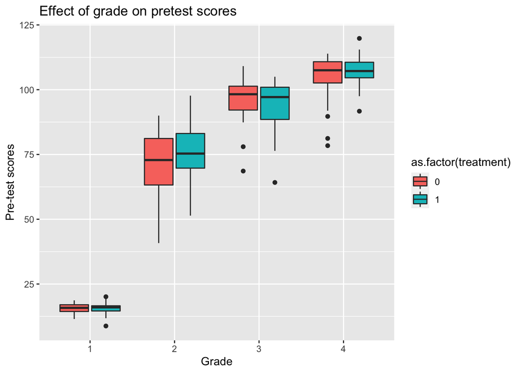

```r
electric %>% ggplot (aes(x = as.factor(grade), y = pre_test, fill = as.factor (treatment))) + geom_boxplot() + labs (x = "Grade", y = "Pre-test scores", title = "Effect of grade on pretest scores")
```

```r
check <- summary (aov( treatment ~ pre_test, data = electric))
check
```

```
##              Df Sum Sq Mean Sq F value Pr(>F)
## pre_test      1   0.04 0.04221   0.167  0.683
## Residuals   190  47.96 0.25241
```

In the graph here, we illustrate the distribution of pretest scores, according to the grade and the treatment groups. We can see for each grade the pretest scores differs, and the median pre test score increases as the grade increases, by which we can infer that their overall performance is increasing as with the grade.

We see run an anova test to find if there is a relation between treatment groups and pre-test scores. We find from this test that there is no statistical difference between two treatment groups, for their pre-test scores. This test is extremely important as it tells us, before the intervention, the pre-test scores were similar, and the difference that we get in the post-test results, happens only because of the intervention, as everyone started at a similar level of pre-test scores. Or else we could not see the impact of treatment, and assess it properly.

*2. What effect does the treatment have on the post test results? Present and interpret the regression results and provide a visualization displaying the effect of treatment.*

```r
reg2 <- lm(post_test ~ treatment, data = electric)
summary(reg2)
```

```
##
## Call:
## lm(formula = post_test ~ treatment, data = electric)
##
## Residuals:
##     Min      1Q  Median      3Q     Max
## -55.778  -9.935   4.872  13.397  23.679
##
## Coefficients:
##             Estimate Std. Error t value Pr(>|t|)
## (Intercept)   94.321      1.794   52.58   <2e-16 ***
## treatment      5.657      2.537    2.23   0.0269 *
## ---
## Signif. codes:  0 '***' 0.001 '**' 0.01 '*' 0.05 '.' 0.1 ' ' 1
##
## Residual standard error: 17.58 on 190 degrees of freedom
## Multiple R-squared:  0.0255, Adjusted R-squared:  0.02037
## F-statistic: 4.973 on 1 and 190 DF,  p-value: 0.02692
```

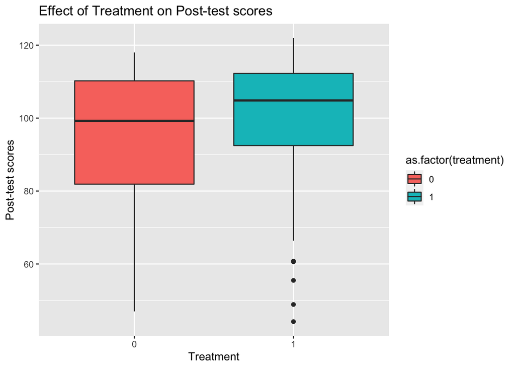

```r
graph2 <- electric %>% ggplot (aes(x = as.factor(treatment), y = post_test,  fill = as.factor (treatment))) + geom_boxplot()  + labs (x = "Treatment", y = "Post-test scores", title = "Effect of Treatment on Post-test scores")
graph2
```

The intercept here represents the test results a person would have gotten if there was no treatment present and there wasn’t any treatment effect. This means that a person would have gotten 94.321 in case there was no treatment and the marks will change by 5.657 in presence of a treatment, and no other variable. The p-value is 0.0269, which is significant and indicates that the effect of treatment has significance.

The box plot here indicates the spread of post test results for the conditions when treatment is present vs when treatment is not present. We can see that the median for the post test increased in the presence of a treatment.

*3. What effect does the pre-test have on the post-test results? Present and interpret the regression results and provide a visualization displaying the effect of treatment.*

```r
reg3 <- lm (post_test ~ pre_test, data = electric)
summary(reg3)
```

```
##
## Call:
## lm(formula = post_test ~ pre_test, data = electric)
##
## Residuals:
##     Min      1Q  Median      3Q     Max
## -23.641  -3.495   0.556   2.912  35.537
##
## Coefficients:
##             Estimate Std. Error t value Pr(>|t|)
## (Intercept) 63.77507    1.42161   44.86   <2e-16 ***
## pre_test     0.46209    0.01782   25.93   <2e-16 ***
## ---
## Signif. codes:  0 '***' 0.001 '**' 0.01 '*' 0.05 '.' 0.1 ' ' 1
##
## Residual standard error: 8.359 on 190 degrees of freedom
## Multiple R-squared:  0.7796, Adjusted R-squared:  0.7785
## F-statistic: 672.2 on 1 and 190 DF,  p-value: < 2.2e-16
```

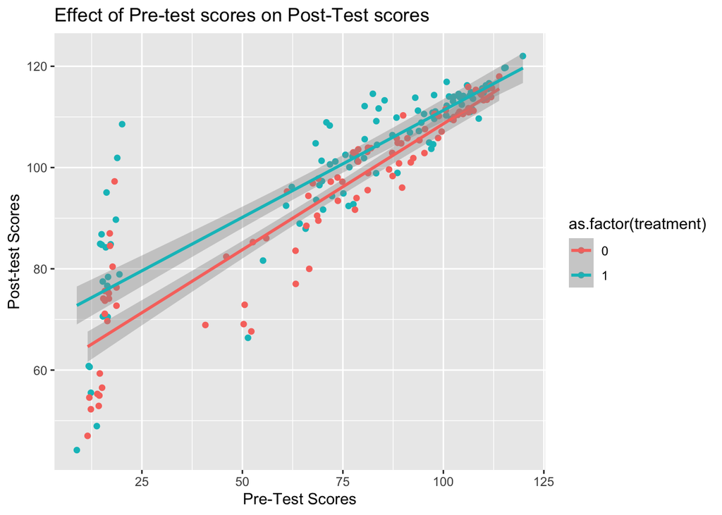

```r
graph3 <- electric %>%  ggplot (aes(x = pre_test, y = post_test , color = as.factor(treatment))) + geom_jitter() + geom_smooth(method = lm) + labs (x = "Pre-Test Scores", y = "Post-test Scores", title = "Effect of Pre-test scores on Post-Test scores")
graph3
```

The intercept here represents the post test results without the presence of any pre-test happening, which is a kind of check. This means the score that a person would get would be 63.77507, if there is no pre-test happening.

The intercept for pre-test is 0.462, which means that the score for post-test would change by 0.462 if there is a pre-test in included.

The graph here presents the relation between the post test and pre-test in the presence of a treatment. The scores are higher when there is a treatment present, which shows the effect of the treatment. The coefficient here is seen to be significant, as the p value is less than 0.05, from which we can infer that the this coefficient has an effect on the post test.

We can also see from the graph that due to the treatment, the post test scores are higher for that group.

*4. Does the effect of treatment depend on grade? Present and interpret the regression results and provide a visualization displaying the effect of treatment.*

```r
reg4 <- lm(effectoftreatment ~ grade + treatment + treatment*grade, data = electric)
summary (reg4)
```

```
##
## Call:
## lm(formula = effectoftreatment ~ grade + treatment + treatment *
##     grade, data = electric)
##
## Residuals:
##     Min      1Q  Median      3Q     Max
## -19.081  -7.331  -2.312   6.038  37.253
##
## Coefficients:
##                 Estimate Std. Error t value Pr(>|t|)
## (Intercept)       59.207      2.687  22.037   <2e-16 ***
## grade            -14.877      1.015 -14.661   <2e-16 ***
## treatment          9.206      3.800   2.423   0.0163 *
## grade:treatment   -2.289      1.435  -1.595   0.1124
## ---
## Signif. codes:  0 '***' 0.001 '**' 0.01 '*' 0.05 '.' 0.1 ' ' 1
##
## Residual standard error: 10.52 on 188 degrees of freedom
## Multiple R-squared:  0.7295, Adjusted R-squared:  0.7251
## F-statistic:   169 on 3 and 188 DF,  p-value: < 2.2e-16
```

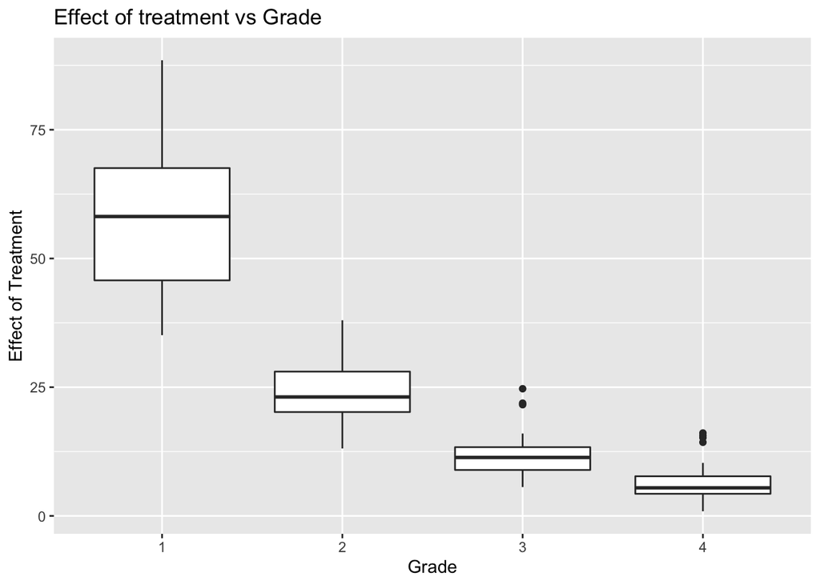

```r
graph4 <- electric %>%  ggplot (aes(x = as.factor(grade), y = effectoftreatment)) + geom_boxplot() + labs (x = "Grade", y = "Effect of Treatment", title = "Effect of treatment vs Grade")
graph4
```

We might infer from this, that the treatment making much of a difference for the higher grade students. Intercept here is 59.207, which means that in the absence of effect of grade and treatment the score that a person would get is 59.207.

The coefficient for grade is -14.877, which means that in the absence of any other variables, and the presence of only grade, the change in the difference between post test and pre test would change by 14.877.

The coefficient for treatment is 9.206, which would mean that in the absence of any other variables and the presence of only treatment variable the effect on the difference between post test and pre test would change by 9.206.

The coefficient for interaction between treatment and grade, is not significant here, which means that there is no significant interaction between both of these variables. By this we could conclude that the effect of treatment does not depend on the grade.

*5. Does the effect of treatment depend on the pretest results? Present and interpret the regression results and provide a visualization displaying the effect of treatment*

```r
reg5 <- lm(effectoftreatment ~ pre_test + treatment + treatment*pre_test, data = electric)
summary (reg5)
```

```
##
## Call:
## lm(formula = effectoftreatment ~ pre_test + treatment + treatment *
##     pre_test, data = electric)
##
## Residuals:
##      Min       1Q   Median       3Q      Max
## -28.5588  -3.0349   0.5343   2.7009  31.0672
##
## Coefficients:
##                    Estimate Std. Error t value Pr(>|t|)
## (Intercept)        58.89008    1.89092  31.144  < 2e-16 ***
## pre_test           -0.50252    0.02398 -20.956  < 2e-16 ***
## treatment          10.15093    2.70645   3.751 0.000235 ***
## pre_test:treatment -0.07500    0.03393  -2.210 0.028285 *
## ---
## Signif. codes:  0 '***' 0.001 '**' 0.01 '*' 0.05 '.' 0.1 ' ' 1
##
## Residual standard error: 7.953 on 188 degrees of freedom
## Multiple R-squared:  0.8454, Adjusted R-squared:  0.8429
## F-statistic: 342.7 on 3 and 188 DF,  p-value: < 2.2e-16
```

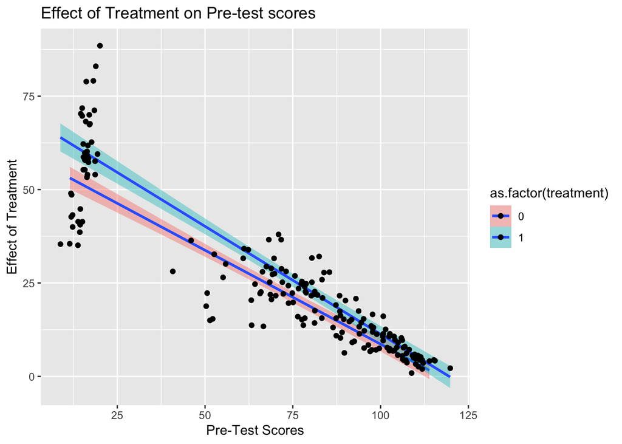

```r
graph5 <- electric %>% ggplot (aes (y = effectoftreatment, x = pre_test, fill = as.factor(treatment)) ) + geom_smooth (method =lm ) + geom_jitter () + labs (x = "Pre-Test Scores", y = "Effect of Treatment", title = "Effect of Treatment on Pre-test scores")
graph5
```

The intercept here is 58.89008, which tells us the the effect of treatment, which is the difference between post test and pre test, will be 58.89008, in the absence of the effect of treatment and any pre-test (pre-test result here might be 0, which means there is no pre-test?)

Coefficient of pre-test : the coefficient of pre-test is -0.5, which tells us, that in the presence of pre-test and no other variables, there would be a change of 0.5, on the difference between post test and pre test.

Coefficient for treatment : the coefficient for treatment is 10.15, which tells us that in the presence of only treatment, and no other variables, there would be a change of 10.15, on the difference between post test and pre test.

The graph here shows the effect of treatment depending on the pre-test, for the groups which have treatment, vs which do not have treatment. It can be interpreted from the graph, that the effect of treatment decreases, as the pre-test scores increase.

*EXTRA POINTS*

*1. Does the effect of the pretest results on the effect of treatment depend on grade? Construct a model with a three-way interaction, provide an interpretation and a visual illustration.*

```r
regex1 <- lm (post_test ~ pre_test + treatment + grade + treatment*grade*pre_test, data = electric)
summary (regex1)
```

```
##
## Call:
## lm(formula = post_test ~ pre_test + treatment + grade + treatment *
##     grade * pre_test, data = electric)
##
## Residuals:
##      Min       1Q   Median       3Q      Max
## -28.4901  -2.3681  -0.0435   3.2124  29.5573
##
## Coefficients:
##                           Estimate Std. Error t value Pr(>|t|)
## (Intercept)               72.07049    4.56749  15.779  < 2e-16 ***
## pre_test                   0.48583    0.05882   8.259  2.8e-14 ***
## treatment                 12.90775    6.91782   1.866 0.063651 .
## grade                    -12.99009    3.84333  -3.380 0.000885 ***
## treatment:grade           -4.24514    6.12691  -0.693 0.489266
## pre_test:treatment        -0.03862    0.08105  -0.477 0.634247
## pre_test:grade             0.09374    0.03281   2.857 0.004772 **
## pre_test:treatment:grade   0.02123    0.05043   0.421 0.674298
## ---
## Signif. codes:  0 '***' 0.001 '**' 0.01 '*' 0.05 '.' 0.1 ' ' 1
##
## Residual standard error: 7.519 on 184 degrees of freedom
## Multiple R-squared:  0.8273, Adjusted R-squared:  0.8207
## F-statistic: 125.9 on 7 and 184 DF,  p-value: < 2.2e-16
```

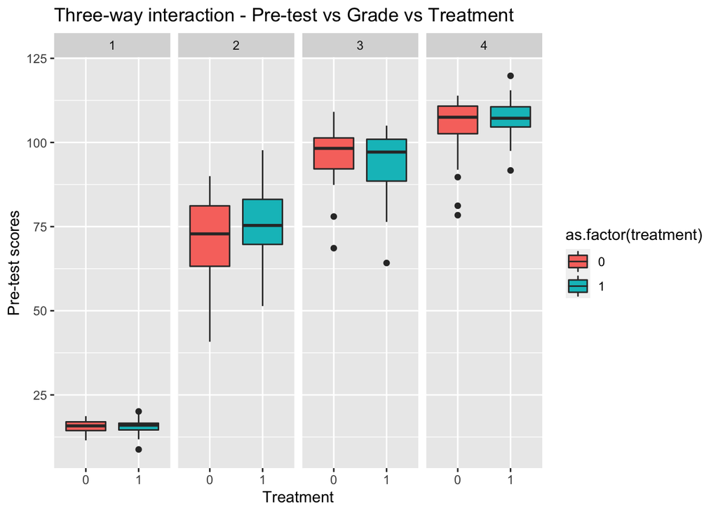

```r
graph6 <- electric %>% ggplot(aes (x = as.factor(treatment), y = pre_test, fill = as.factor(treatment))) +
geom_boxplot() + facet_grid(cols = vars(grade))+ labs (x = "Treatment", y = "Pre-test scores", title = "Three-way interaction - Pre-test vs Grade vs Treatment ")
graph6
```

*2. Check (to the best of your ability) that none of the variables can be used to predict treatment.*

```r
regex2  <- lm (treatment ~ pre_test + grade, data = electric )
summary(regex2)
```

```
##
## Call:
## lm(formula = treatment ~ pre_test + grade, data = electric)
##
## Residuals:
##      Min       1Q   Median       3Q      Max
## -0.56102 -0.49007  0.00085  0.49988  0.55128
##
## Coefficients:
##              Estimate Std. Error t value Pr(>|t|)
## (Intercept)  0.493008   0.091163   5.408 1.91e-07 ***
## pre_test     0.002042   0.002315   0.882    0.379
## grade       -0.057884   0.074053  -0.782    0.435
## ---
## Signif. codes:  0 '***' 0.001 '**' 0.01 '*' 0.05 '.' 0.1 ' ' 1
##
## Residual standard error: 0.5029 on 189 degrees of freedom
## Multiple R-squared:  0.004099,   Adjusted R-squared:  -0.00644
## F-statistic: 0.3889 on 2 and 189 DF,  p-value: 0.6783
```

#treatment should not depend on the grade, and pretest and hence our null hypothesis should be true, hence p values should not be significant Here we conduct a test to see the if the grade, and the pretest scores effect the treatment. Ideally we want to observe that there is no effect of these variables on the treatment, only then the treatment might be called effective. Hence our null hypothesis - that there is no effect of treatment on pre-test and grade has to be true. From this regression model, we see that the coefficients of pre-test and grade, have pvalues more than 0.05, suggesting that the null hypothesis is true, and there is no significant effect of these variables on the treatment

*3. Construct a coefplot with the coefficients of your most complex model (you can use this as a resource: https://rdrr.io/cran/GGally/man/ggcoef.html Links to an external site.)* #coef plot : shows coefficients in a graph form Our most complex model is the first one with three way interactions.

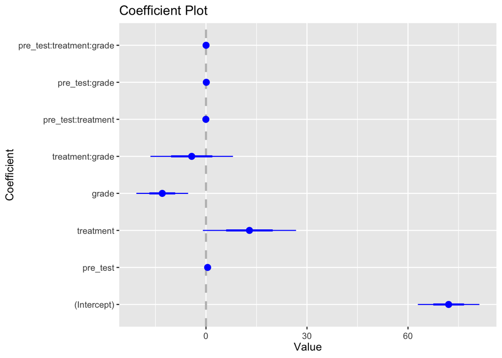

```r
coefplot(lm (post_test ~ pre_test + treatment + grade + treatment*grade*pre_test, data = electric))
```

*4. Read the following document: https://www.r-bloggers.com/2010/11/example-8-14-generating-standardized-regression-coefficients/ Links to an external site.*

*Rerun your most complex model with the standardized coefficients. Give the interpretation of the coefficients and based on this interpretation decide on how effective the intervention is.*

```r
library(QuantPsyc)
reg4 <- lm.beta(lm(post_test ~ pre_test + treatment + grade + treatment*grade*pre_test, data = electric))
reg4
```

```
##                 pre_test                treatment                    grade
##              0.928325906              0.364370506             -0.776037292
##          treatment:grade       pre_test:treatment           pre_test:grade
##             -8.111590209             -0.001090259              0.005599827
## pre_test:treatment:grade
##              0.040562967
```

```r
regex1 <- lm (post_test ~ pre_test + treatment + grade + treatment*grade*pre_test, data = electric)
regex1
```

```
##
## Call:
## lm(formula = post_test ~ pre_test + treatment + grade + treatment *
##     grade * pre_test, data = electric)
##
## Coefficients:
##              (Intercept)                  pre_test                 treatment
##                 72.07049                   0.48583                  12.90775
##                    grade           treatment:grade        pre_test:treatment
##                -12.99009                  -4.24514                  -0.03862
##           pre_test:grade  pre_test:treatment:grade
##                  0.09374                   0.02123
```

standardized coefficients mean that the variance is 1 From this model we can see that change 1 standard deviation of pretest will be almost thrice the impact of the change in one standard deviation effect of the treatment. Even the change in one standard deviation of te grade has almost twice the impact of one standard deviation change in treatment. Hence, we might be able to conclude that the effect of the intervention might not be as effective as the effect of pretest and grade.